# DESCRIPTION

were are currently updating our project and you will be regularly updated and for more infomation notes,pdf,code,full png ans svg map you can follow us on following and DM on social media platforms.

`instagram` https://www.instagram.com/ahanger.asif?igsh=MXZiczBreWgwd25iMA==

`facebook` https://www.facebook.com/ahangerasifahanger.asif

```python
print("HI Asif ")
```

```
HI Asif
```

```python
import numpy as np
```

```python
x = [range(20)]

y = [np.sin(i) for i in x]
y
```

```
[array([ 0.        ,  0.84147098,  0.90929743,  0.14112001, -0.7568025 ,
        -0.95892427, -0.2794155 ,  0.6569866 ,  0.98935825,  0.41211849,
        -0.54402111, -0.99999021, -0.53657292,  0.42016704,  0.99060736,
         0.65028784, -0.28790332, -0.96139749, -0.75098725,  0.14987721])]
```

```python
import pandas as pd
import numpy as numpy
import matplotlib.pyplot as pyplot
import seaborn as sns

from sklearn.linear_model import LinearRegression
```

```python
df =  sns.load_dataset('tips')
df.head()
```

|  | total_bill | tip | sex | smoker | day | time | size |
| --- | --- | --- | --- | --- | --- | --- | --- |
| 0 | 16.99 | 1.01 | Female | No | Sun | Dinner | 2 |
| 1 | 10.34 | 1.66 | Male | No | Sun | Dinner | 3 |
| 2 | 21.01 | 3.50 | Male | No | Sun | Dinner | 3 |
| 3 | 23.68 | 3.31 | Male | No | Sun | Dinner | 2 |
| 4 | 24.59 | 3.61 | Female | No | Sun | Dinner | 4 |

```python
X = df[['total_bill']]
X.head()
```

|  | total_bill |
| --- | --- |
| 0 | 16.99 |
| 1 | 10.34 |
| 2 | 21.01 |
| 3 | 23.68 |
| 4 | 24.59 |

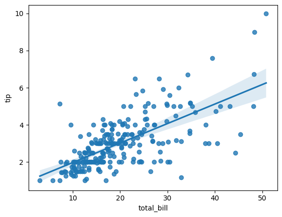

```python
sns.regplot(x='total_bill', y='tip', data=df)
```

## prediction on the bses of single input

```python
X = df[['total_bill']]   # x - axis

Y = df[['tip']]   # y-axis
```

```python
model = LinearRegression()

model.fit(X,Y)   # model trained
```

```
LinearRegression()
```

```python
# lets predict the tip for an unknown total_bill

model.predict([[32]])
```

```
array([[4.28105417]])
```

```python
# lets predict the tip for an unknown total_bill

model.predict([[150]])
```

```
array([[16.67394722]])
```

## intermediate ML

```python
df.head()
```

|  | total_bill | tip | sex | smoker | day | time | size |
| --- | --- | --- | --- | --- | --- | --- | --- |
| 0 | 16.99 | 1.01 | Female | No | Sun | Dinner | 2 |
| 1 | 10.34 | 1.66 | Male | No | Sun | Dinner | 3 |
| 2 | 21.01 | 3.50 | Male | No | Sun | Dinner | 3 |
| 3 | 23.68 | 3.31 | Male | No | Sun | Dinner | 2 |
| 4 | 24.59 | 3.61 | Female | No | Sun | Dinner | 4 |

## multivariate linear regression

we can use multiple input features to predict the output variable. In this case, we will use both 'total_bill' and 'size' as input features to predict 'tip'.

`python`

```python
# multivariate linear regression

x = df[['total_bill', 'size']]

y = df[['tip']]

model = LinearRegression()

model.fit(x,y)
```

```
LinearRegression()
```

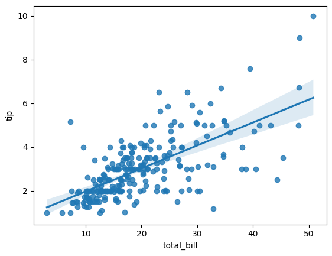

```python
sns.regplot(x='total_bill', y='tip', data=df)
```

```python
model.predict([[32, 2]])
```

```
array([[4.02096711]])
```

```python
df.head()
```

[output not shown]

```python
# encoding categorical variables
df = sns.load_dataset('tips')
df['smoker_num'] = df['smoker'].map({'Yes':1, 'No':0})
df.head()
```

|  | total_bill | tip | sex | smoker | day | time | size | smoker_num |
| --- | --- | --- | --- | --- | --- | --- | --- | --- |
| 0 | 16.99 | 1.01 | Female | No | Sun | Dinner | 2 | 0 |
| 1 | 10.34 | 1.66 | Male | No | Sun | Dinner | 3 | 0 |
| 2 | 21.01 | 3.50 | Male | No | Sun | Dinner | 3 | 0 |
| 3 | 23.68 | 3.31 | Male | No | Sun | Dinner | 2 | 0 |
| 4 | 24.59 | 3.61 | Female | No | Sun | Dinner | 4 | 0 |

```python
x =  df[['total_bill', 'size', 'smoker_num']]
y = df[['tip']]

model = LinearRegression()
model.fit(x,y)
```

```
LinearRegression()
```

```python
model.predict([[32, 2,1]])
```

```
array([[3.99067456]])
```

# classification task

```python
df = sns.load_dataset('tips')
df.head()
```

|  | total_bill | tip | sex | smoker | day | time | size |
| --- | --- | --- | --- | --- | --- | --- | --- |
| 0 | 16.99 | 1.01 | Female | No | Sun | Dinner | 2 |
| 1 | 10.34 | 1.66 | Male | No | Sun | Dinner | 3 |
| 2 | 21.01 | 3.50 | Male | No | Sun | Dinner | 3 |
| 3 | 23.68 | 3.31 | Male | No | Sun | Dinner | 2 |
| 4 | 24.59 | 3.61 | Female | No | Sun | Dinner | 4 |

```python
from sklearn.linear_model import LogisticRegression
# classification task
x = df[['total_bill', 'size', 'tip']]
# df['smoker_num'] = df['smoker'].map({'Yes':1, 'No':0})
y = df['smoker']
# model selextion
model = LogisticRegression()

# firt the model
model.fit(x,y)
```

```
LogisticRegression()
```

```python
model.predict([[32, 2, 1]])
model.predict([[10, 1, 0]])
model.predict([[50, 4, 1]])
```

```
array(['Yes'], dtype=object)
```

## binary classification task

```python
# binary classification
## binary classification task
df = sns.load_dataset('tips')
df.head()
from sklearn.linear_model import LogisticRegression
x = df[['total_bill', 'size', 'tip']]
y = df['smoker']
model = LogisticRegression()
model.fit(x,y)

model.predict([[32, 2,1]])
```

```
array(['Yes'], dtype=object)
```

## Logistic Regression

now we will use Logistic Regression for classification task. We will predict whether a person is a smoker or not based on 'total_bill', 'size', and 'tip'.

`python`

# it uses sigmoid function

The Logistic Regression model uses the sigmoid function to map predicted values to probabilities between 0 and 1. This allows us to classify the input data into two categories (smoker or non-smoker) based on a threshold (usually 0.5).

```python
# naive bayes classifier
# naive

from sklearn.naive_bayes import GaussianNB
# parameters
x = df[['total_bill', 'size', 'tip']]
# target
y = df['smoker']

# algoeirthm selection
model = GaussianNB()

# fit the model
model.fit(x,y)
# predict
model.predict([[32, 2,1]])
```

```
array(['Yes'], dtype='<U3')
```

# now we will learn disicion tree classifier

```python
# disicion tree classifier
from sklearn.tree import DecisionTreeClassifier
x = df[['total_bill', 'size', 'tip']]
y = df['smoker']

model = DecisionTreeClassifier()

model.fit(x,y)

model.predict([[32, 2,1]])
```

```
array(['Yes'], dtype=object)
```

```python
# disicion tree classifier
from sklearn.tree import DecisionTreeRegressor

x = df[['total_bill', 'size']]  # features

y = df['tip']   # target

model = DecisionTreeRegressor()   # model selection

model.fit(x,y)   #  fit the model


model.predict([[32, 2]])  #  predict
```

```
array([3.18])
```

and three are more algorithms for classification task like SVM, KNN, Naive Bayes etc. you can find the documentation for these algorithms on the official scikit-learn website: https://scikit-learn.org/stable/supervised_learning.html

# Error Metrics for Classification

there error in the model prediction can be measured using various metrics such as accuracy, precision, recall, F1-score, and ROC-AUC. These metrics help evaluate the performance of classification models and determine how well they are able to classify the input data into the correct categories.

how can we minimize the error in classification task? we can minimize the error in classification task by using various techniques such as feature selection, hyperparameter tuning, cross-validation, and ensemble methods. Feature selection involves selecting the most relevant features that contribute to the classification task, while hyperparameter tuning involves optimizing the parameters of the model to improve its performance. Cross-validation helps to evaluate the model's performance on different subsets of the data, while ensemble methods combine multiple models to improve overall accuracy and reduce errors.

## train test split

### ususally split is 80% train and 20% test

we will split the data into training and testing sets to evaluate the performance of our classification model. The training set will be used to train the model, while the testing set will be used to evaluate its performance on unseen data. This helps to ensure that the model is able to generalize well to new data and is not overfitting to the training data.

# root mean square error (RMSE)

The root mean square error (RMSE) is a commonly used metric to evaluate the performance of regression models. It measures the average magnitude of the errors between the predicted and actual values, with a lower RMSE indicating better model performance. RMSE is calculated by taking the square root of the average of the squared differences between the predicted and actual values.

the formulla for RMSE is: [ RMSE = \sqrt{\frac{1}{n} \sum_{i=1}^{n} (y_i - \hat{y}_i)^2} ] where:

- ( y_i ) is the actual value
- ( \hat{y}_i ) is the predicted value
- ( n ) is the number of observations

## what is confusion matrix?

A confusion matrix is a table that is used to evaluate the performance of a classification model. It summarizes the number of correct and incorrect predictions made by the model, broken down by each class. The confusion matrix typically includes four values: true positives (TP), true negatives (TN), false positives (FP), and false negatives (FN). These values can be used to calculate various performance metrics such as accuracy, precision, recall, and F1-score.

```python
#Regreession mTRetrics
import numpy as np
import pandas as pd
import seaborn as sns
```

```python
df = sns.load_dataset('tips')
df.head()
x = df[['total_bill', 'size']]

y = df['tip']
```

```python
# regression matrixcs

from sklearn.model_selection import train_test_split
x_train, x_test, y_train, y_test = train_test_split(x, y, test_size=0.2, random_state=42)  # randomstate for reproducibility

# cal lthe model
model = LinearRegression()

model.fit(x_train, y_train) # fit the model on train data


y_pred = model.predict(x_test)  # predict on test data
```

```python
# matric to evaluate the model
from sklearn.metrics import mean_squared_error, r2_score,mean_absolute_error

mse = mean_squared_error(y_test, y_pred)

rmse = np.sqrt(mse)

mae = mean_absolute_error(y_test, y_pred)
```

## evaluating the model

how can we evaluate the performance of our regression model? we can evaluate the performance of our regression model using various metrics such as mean squared error (MSE), root mean squared error (RMSE), mean absolute error (MAE), and R-squared (R2). These metrics help to quantify the difference between the predicted and actual values, and provide insights into how well the model is able to fit the data.

```python
# we will print the metrics and see how well our model is performing
print("Mean Squared Error (MSE):", mse)
print("Root Mean Squared Error (RMSE):", rmse)
print("Mean Absolute Error (MAE):", mae)
print("R-squared (R2 ):", r2_score(y_test, y_pred))
### by the above matacies we get the idea about how well our model is performing in classification task.

# if the mse is close to 1 then our model is performing well
### by the above matacies we get the idea about how well our model is performing in classification task.
### by the above matacies we get the idea about how well our model is performing in classification task.
```

```
Mean Squared Error (MSE): 0.6485996190543517
Root Mean Squared Error (RMSE): 0.8053568271607013
Mean Absolute Error (MAE): 0.6639235737596481
R-squared (R2 ): 0.4811084097989491
```

# hypertuning ofthe model

we can hypertune the model using techniques such as grid search and random search to find the optimal hyperparameters that improve the model's performance. This involves testing different combinations of hyperparameters and selecting the ones that yield the best results based on evaluation metrics such as accuracy, precision, recall, or F1-score.

# overfitting and underfitting

Overfitting occurs when a model learns the training data too well, capturing noise and fluctuations that do not generalize to new data. This results in high accuracy on the training set but poor performance on unseen data. Underfitting, on the other hand, happens when a model is too simple to capture the underlying patterns in the data, leading to poor performance on both the training and testing sets. To mitigate overfitting, techniques such as cross-validation, regularization, and pruning can be employed. To address underfitting, one can consider using more complex models or adding more relevant features to the dataset.